# Joel update 6/2/17

Liz

June 2, 2017

Load necessary libraries:

Import data:

Subsetting by temperature

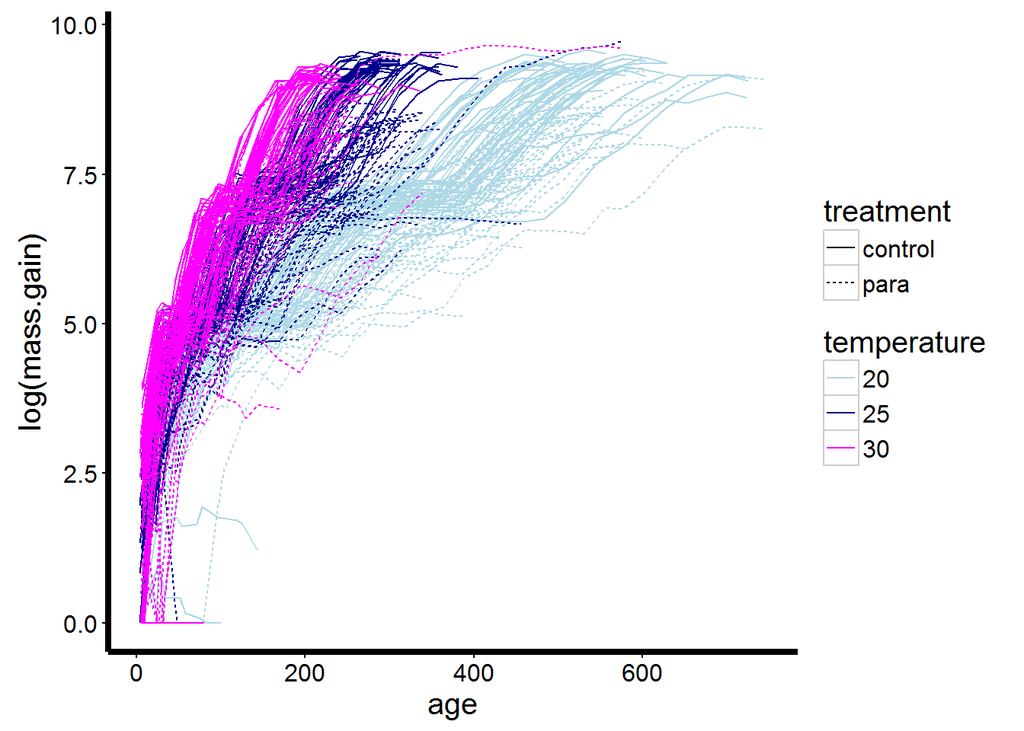

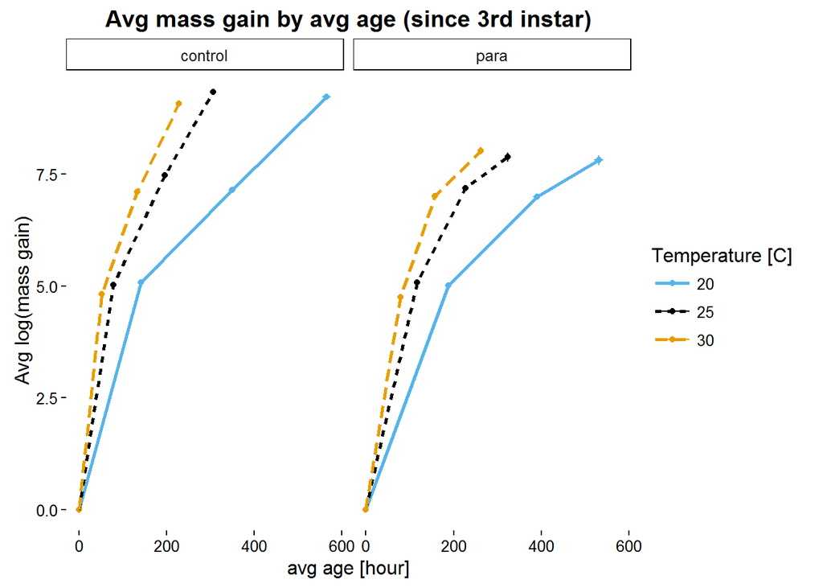

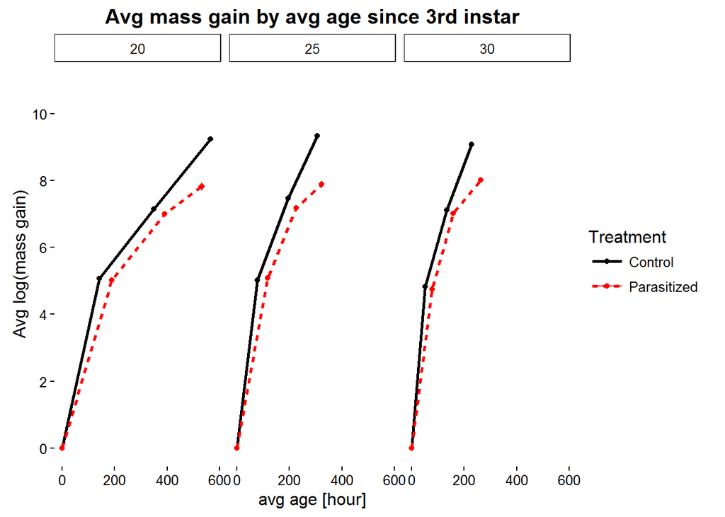

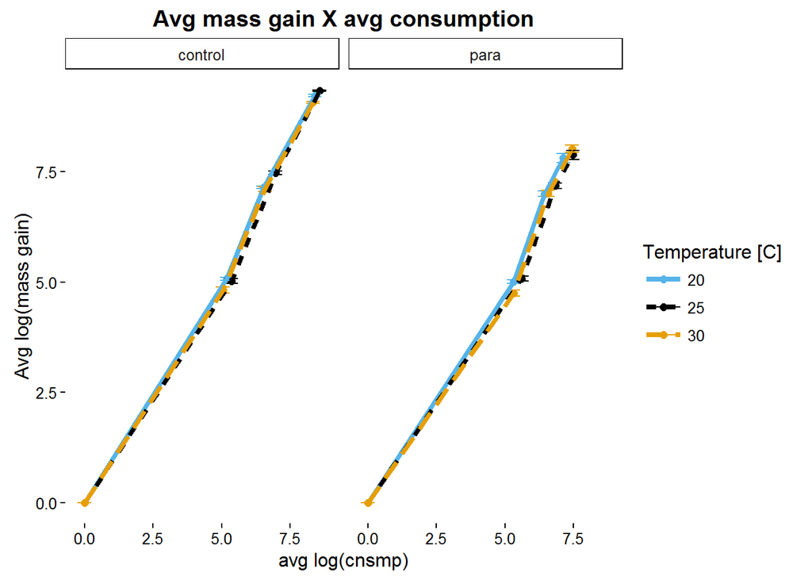

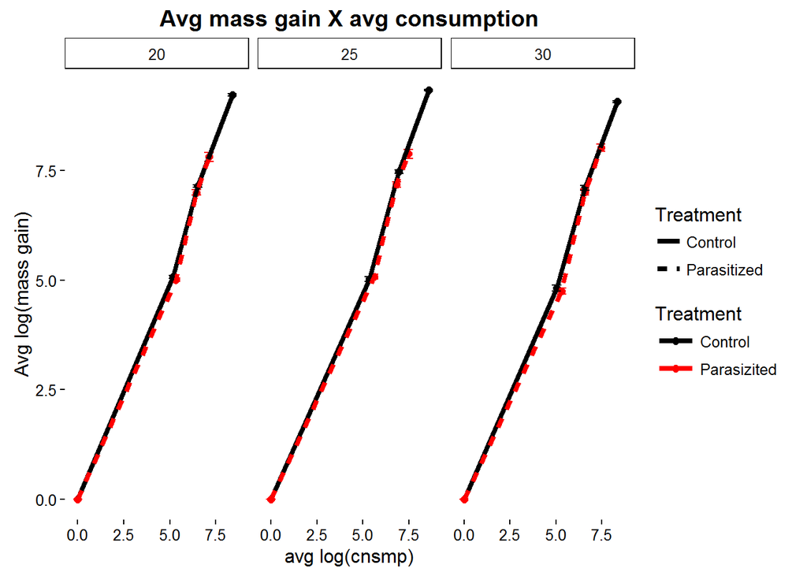

Kate’s idea: add mass at 3rd as a fixed effect–if other fixed effects are still significant, then they should be independent of mass at 3rd

```r
mg.mod5<-lme(log.mg~temp*treatment*poly(age,2)+log.mT0,random=~1|bug.id,data=cpt,method='ML',na.action=na.omit)
anova(mg.mod5)
```

```
##                             numDF denDF   F-value p-value
## (Intercept)                     1  5541 26394.651  <.0001
## temp                            2   278     1.410  0.2458
## treatment                       1   278   117.104  <.0001
## poly(age, 2)                    2  5541 31044.746  <.0001
## log.mT0                         1   278    47.917  <.0001
## temp:treatment                  2   278     4.767  0.0092
## temp:poly(age, 2)               4  5541   649.912  <.0001
## treatment:poly(age, 2)          2  5541   150.147  <.0001
## temp:treatment:poly(age, 2)     4  5541    19.421  <.0001
```

```r
summary(mg.mod5)
```

```
## Linear mixed-effects model fit by maximum likelihood
##  Data: cpt
##        AIC      BIC    logLik
##   9956.966 10097.08 -4957.483
##
## Random effects:
##  Formula: ~1 | bug.id
##         (Intercept)  Residual
## StdDev:    0.585124 0.5227118
##
## Fixed effects: log.mg ~ temp * treatment * poly(age, 2) + log.mT0
##                                         Value Std.Error   DF   t-value
## (Intercept)                           1.91982  0.479424 5541   4.00442
## temp25                                1.15381  0.136106  278   8.47731
## temp30                                1.18385  0.155676  278   7.60459
## treatmentpara                        -0.20355  0.125495  278  -1.62202
## poly(age, 2)1                       128.53819  1.007319 5541 127.60427
## poly(age, 2)2                       -26.50322  0.999517 5541 -26.51603
## log.mT0                               0.88627  0.122466  278   7.23685
## temp25:treatmentpara                 -0.54719  0.179394  278  -3.05020
## temp30:treatmentpara                 -0.09942  0.194123  278  -0.51214
## temp25:poly(age, 2)1                 -1.40297  5.515279 5541  -0.25438
## temp30:poly(age, 2)1                -75.70260 12.755070 5541  -5.93510
## temp25:poly(age, 2)2                -64.27425  4.441277 5541 -14.47202
## temp30:poly(age, 2)2               -120.96300  7.827674 5541 -15.45325
## treatmentpara:poly(age, 2)1         -15.09349  1.388041 5541 -10.87395
## treatmentpara:poly(age, 2)2           5.98843  1.405406 5541   4.26100
## temp25:treatmentpara:poly(age, 2)1    9.28900  6.478228 5541   1.43388
## temp30:treatmentpara:poly(age, 2)1   84.52851 13.503458 5541   6.25977
## temp25:treatmentpara:poly(age, 2)2   23.91388  5.263468 5541   4.54337
## temp30:treatmentpara:poly(age, 2)2   51.91046  8.399247 5541   6.18037
##                                    p-value
## (Intercept)                         0.0001
## temp25                              0.0000
## temp30                              0.0000
## treatmentpara                       0.1059
## poly(age, 2)1                       0.0000
## poly(age, 2)2                       0.0000
## log.mT0                             0.0000
## temp25:treatmentpara                0.0025
```

[output cut: 99 more lines]

```
## temp25:poly(age, 2)2
## temp30:poly(age, 2)2
## treatmentpara:poly(age, 2)1
## treatmentpara:poly(age, 2)2
## temp25:treatmentpara:poly(age, 2)1
## temp30:treatmentpara:poly(age, 2)1
## temp25:treatmentpara:poly(age, 2)2
## temp30:treatmentpara:poly(age, 2)2  0.045
##
## Standardized Within-Group Residuals:
##        Min         Q1        Med         Q3        Max
## -6.6316694 -0.4497665  0.1210506  0.6114641  3.8536856
##
## Number of Observations: 5838
## Number of Groups: 285
```

```r
mg.mod6<-lme(log.mg~temp*treatment*poly(age,2),random=~1|bug.id,data=cpt,method='ML',na.action=na.omit)
anova(mg.mod6,mg.mod5)
```

```
##         Model df       AIC      BIC    logLik   Test L.Ratio p-value
## mg.mod6     1 20 10003.248 10136.69 -4981.624
## mg.mod5     2 21  9956.966 10097.08 -4957.483 1 vs 2 48.2828  <.0001
```

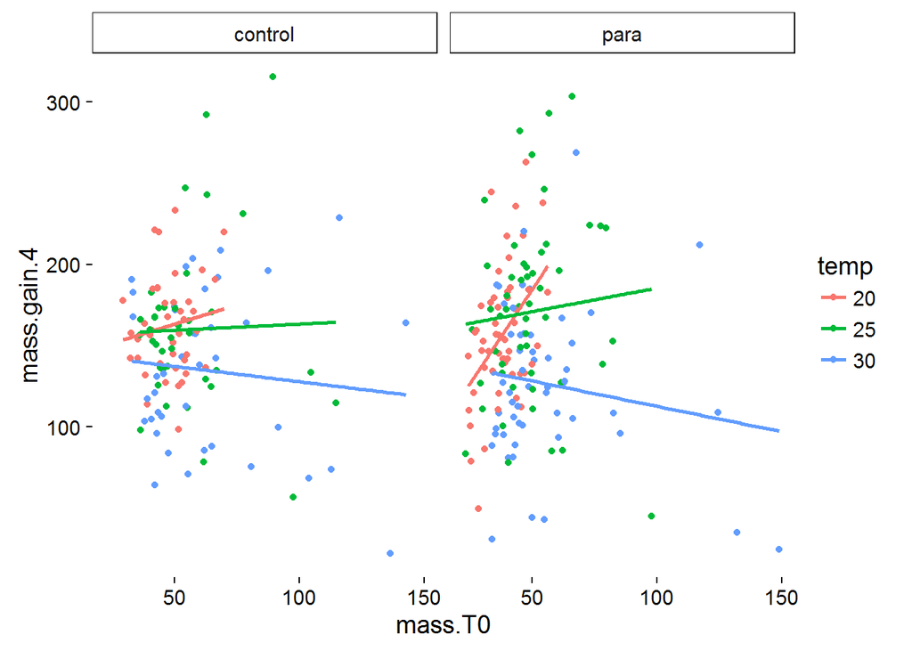

Mass at the 3rd instar seems to have some correlation with mass gained at the 4th instar (which makes sense). The steepest slope is in the parasitized treatment at 20C, where there is a strongly positive correlation between mass at the 3rd instar and mass gained by the 4th instar.There seem to be some “outliers” at 30, maybe should exclude anything above 100.

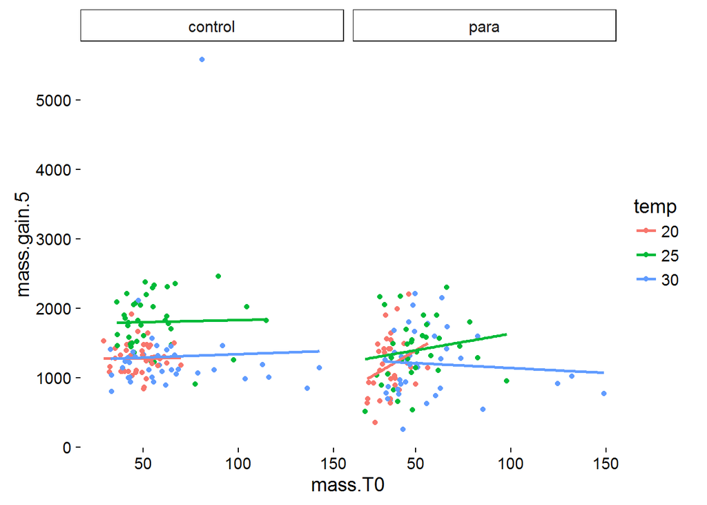

There is mostly no strong correlation between mass at 3rd and mass gained by the 5th instar. The parasitized treatment retains some positive slope, but it is much less steep than for mass gained at 4th.

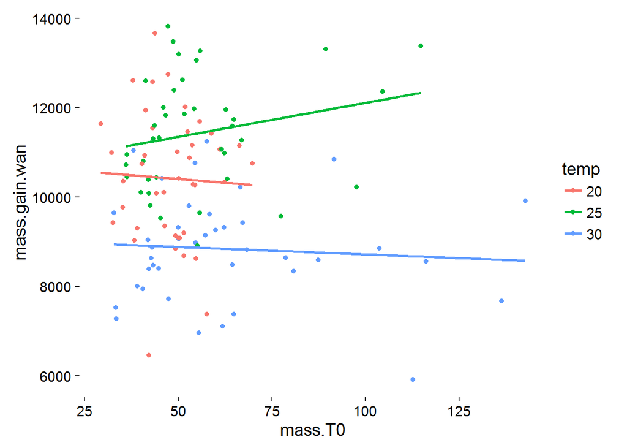

Doesn’t seem to be any strong correlation between mass at the 3rd and mass gained by wandering (control treatment only)

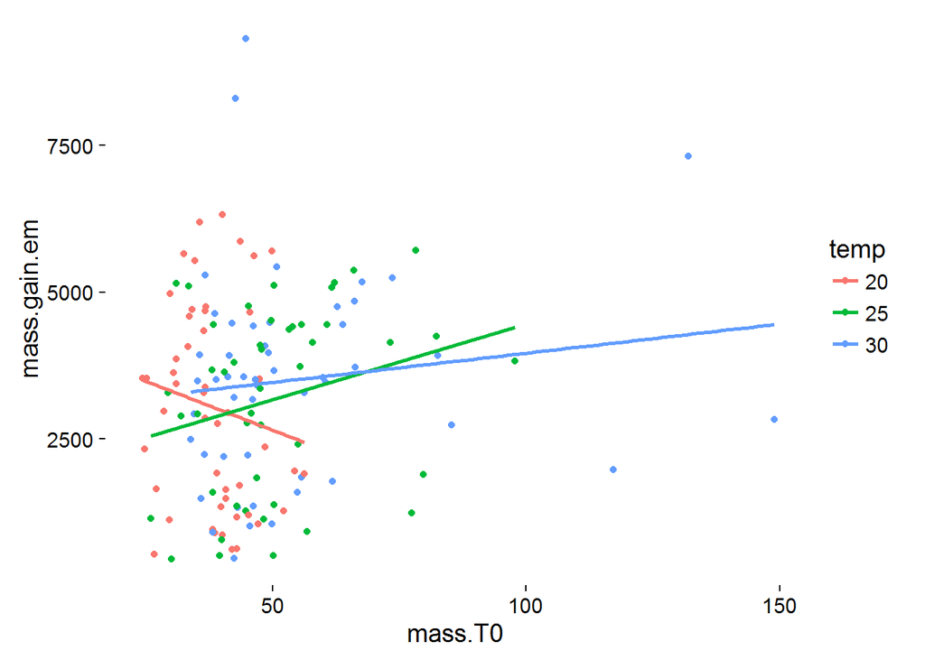

Interestingly, the correlation between mass at 3rd and mass gained by wasp emergence has switched directions for the 20C group–at 4th and 5th, it was positive, and at emergence, it is negative. 30 has also switched, from being weakly negative to being weakly positive (even including possible “outliers” of too large 3rds >100 mg).

Preliminary mixed effect model of consumption by temp, treatment and age (and mass at 3rd), with ID as a random factor

```r
cnsmp.mod<-lme(log.cnsmp~treatment*temp*poly(age,2)+log.mT0,random=~1|bug.id,data=cpt,method="ML",na.action = na.omit)
anova(cnsmp.mod)
```

```
##                             numDF denDF   F-value p-value
## (Intercept)                     1  5289 258432.19  <.0001
## treatment                       1   278    140.05  <.0001
## temp                            2   278     80.60  <.0001
## poly(age, 2)                    2  5289  30984.95  <.0001
## log.mT0                         1   278     55.71  <.0001
## treatment:temp                  2   278      4.32  0.0142
## treatment:poly(age, 2)          2  5289    233.99  <.0001
## temp:poly(age, 2)               4  5289    619.50  <.0001
## treatment:temp:poly(age, 2)     4  5289     33.93  <.0001
```

```r
summary(cnsmp.mod)
```

```
## Linear mixed-effects model fit by maximum likelihood
##  Data: cpt
##        AIC      BIC    logLik
##   5578.648 5717.836 -2768.324
##
## Random effects:
##  Formula: ~1 | bug.id
##         (Intercept)  Residual
## StdDev:   0.1631374 0.3824253
##
## Fixed effects: log.cnsmp ~ treatment * temp * poly(age, 2) + log.mT0
##                                         Value Std.Error   DF   t-value
## (Intercept)                           3.92150  0.151166 5289  25.94161
## treatmentpara                        -0.13938  0.038467  278  -3.62329
## temp25                                1.03830  0.048208  278  21.53799
## temp30                                0.88717  0.082802  278  10.71442
## poly(age, 2)1                        96.54289  0.761821 5289 126.72653
## poly(age, 2)2                       -21.65966  0.780144 5289 -27.76366
## log.mT0                               0.31840  0.038662  278   8.23554
## treatmentpara:temp25                 -0.19970  0.060913  278  -3.27843
## treatmentpara:temp30                  0.29452  0.091699  278   3.21180
## treatmentpara:poly(age, 2)1         -16.49715  1.019389 5289 -16.18337
## treatmentpara:poly(age, 2)2           4.54368  1.033278 5289   4.39735
## temp25:poly(age, 2)1                 -4.22292  4.559043 5289  -0.92627
## temp30:poly(age, 2)1                -78.73306 10.921370 5289  -7.20908
## temp25:poly(age, 2)2                -44.36429  3.505210 5289 -12.65667
## temp30:poly(age, 2)2               -107.37108  6.380321 5289 -16.82848
## treatmentpara:temp25:poly(age, 2)1   18.66037  5.066269 5289   3.68326
## treatmentpara:temp30:poly(age, 2)1   99.82818 11.289339 5289   8.84269
## treatmentpara:temp25:poly(age, 2)2   19.51678  3.978145 5289   4.90600
## treatmentpara:temp30:poly(age, 2)2   70.33469  6.692045 5289  10.51019
##                                    p-value
## (Intercept)                         0.0000
## treatmentpara                       0.0003
## temp25                              0.0000
## temp30                              0.0000
## poly(age, 2)1                       0.0000
## poly(age, 2)2                       0.0000
## log.mT0                             0.0000
## treatmentpara:temp25                0.0012
```

[output cut: 99 more lines]

```
## temp25:poly(age, 2)1
## temp30:poly(age, 2)1
## temp25:poly(age, 2)2
## temp30:poly(age, 2)2
## treatmentpara:temp25:poly(age, 2)1
## treatmentpara:temp30:poly(age, 2)1
## treatmentpara:temp25:poly(age, 2)2
## treatmentpara:temp30:poly(age, 2)2  0.040
##
## Standardized Within-Group Residuals:
##         Min          Q1         Med          Q3         Max
## -11.7001576  -0.4445427   0.1444646   0.5899226   4.6614287
##
## Number of Observations: 5586
## Number of Groups: 285
```

```r
cnsmp.mod2<-lme(log.cnsmp~treatment*temp*poly(age,2),random=~1|bug.id,data=cpt,method="ML",na.action = na.omit)
anova(cnsmp.mod2)
```

```
##                             numDF denDF   F-value p-value
## (Intercept)                     1  5289 210187.46  <.0001
## treatment                       1   279    115.13  <.0001
## temp                            2   279     65.78  <.0001
## poly(age, 2)                    2  5289  30895.55  <.0001
## treatment:temp                  2   279      2.22  0.1104
## treatment:poly(age, 2)          2  5289    234.56  <.0001
## temp:poly(age, 2)               4  5289    617.51  <.0001
## treatment:temp:poly(age, 2)     4  5289     33.97  <.0001
```

```r
summary(cnsmp.mod2)
```

```
## Linear mixed-effects model fit by maximum likelihood
##  Data: cpt
##        AIC      BIC    logLik
##   5638.579 5771.139 -2799.289
##
## Random effects:
##  Formula: ~1 | bug.id
##         (Intercept)  Residual
## StdDev:   0.1857292 0.3825629
##
## Fixed effects: log.cnsmp ~ treatment * temp * poly(age, 2)
##                                         Value Std.Error   DF   t-value
## (Intercept)                           5.14466  0.031014 5289 165.88076
## treatmentpara                        -0.21187  0.041670  279  -5.08449
## temp25                                1.08234  0.051865  279  20.86839
## temp30                                0.95068  0.084968  279  11.18873
## poly(age, 2)1                        96.50871  0.763320 5289 126.43285
## poly(age, 2)2                       -21.64375  0.781290 5289 -27.70259
## treatmentpara:temp25                 -0.17075  0.066234  279  -2.57807
## treatmentpara:temp30                  0.33447  0.095246  279   3.51163
## treatmentpara:poly(age, 2)1         -16.49250  1.020952 5289 -16.15404
## treatmentpara:poly(age, 2)2           4.48213  1.034834 5289   4.33125
## temp25:poly(age, 2)1                 -4.19921  4.566877 5289  -0.91949
## temp30:poly(age, 2)1                -79.50752 10.943949 5289  -7.26498
## temp25:poly(age, 2)2                -44.43528  3.509890 5289 -12.66002
## temp30:poly(age, 2)2               -107.73517  6.391046 5289 -16.85720
## treatmentpara:temp25:poly(age, 2)1   18.22138  5.077628 5289   3.58856
## treatmentpara:temp30:poly(age, 2)1  100.53867 11.315578 5289   8.88498
## treatmentpara:temp25:poly(age, 2)2   19.33172  3.985339 5289   4.85071
## treatmentpara:temp30:poly(age, 2)2   70.72622  6.704433 5289  10.54917
##                                    p-value
## (Intercept)                         0.0000
## treatmentpara                       0.0000
## temp25                              0.0000
## temp30                              0.0000
## poly(age, 2)1                       0.0000
## poly(age, 2)2                       0.0000
## treatmentpara:temp25                0.0104
## treatmentpara:temp30                0.0005
## treatmentpara:poly(age, 2)1         0.0000
```

[output cut: 74 more lines]

```
## temp25:poly(age, 2)1
## temp30:poly(age, 2)1
## temp25:poly(age, 2)2
## temp30:poly(age, 2)2
## treatmentpara:temp25:poly(age, 2)1
## treatmentpara:temp30:poly(age, 2)1  0.018
## treatmentpara:temp25:poly(age, 2)2  0.823     -0.006
## treatmentpara:temp30:poly(age, 2)2 -0.008      0.932      0.040
##
## Standardized Within-Group Residuals:
##         Min          Q1         Med          Q3         Max
## -11.5275577  -0.4388378   0.1407112   0.5895528   4.6410193
##
## Number of Observations: 5586
## Number of Groups: 285
```

```r
anova(cnsmp.mod,cnsmp.mod2)
```

```
##            Model df      AIC      BIC    logLik   Test  L.Ratio p-value
## cnsmp.mod      1 21 5578.648 5717.836 -2768.324
## cnsmp.mod2     2 20 5638.579 5771.139 -2799.289 1 vs 2 61.93138  <.0001
```

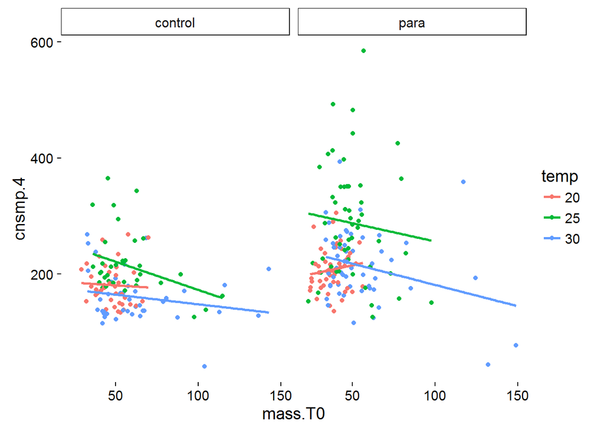

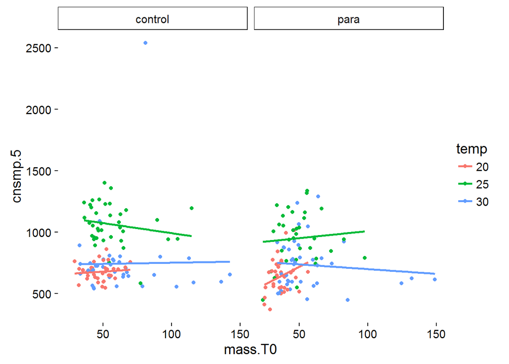

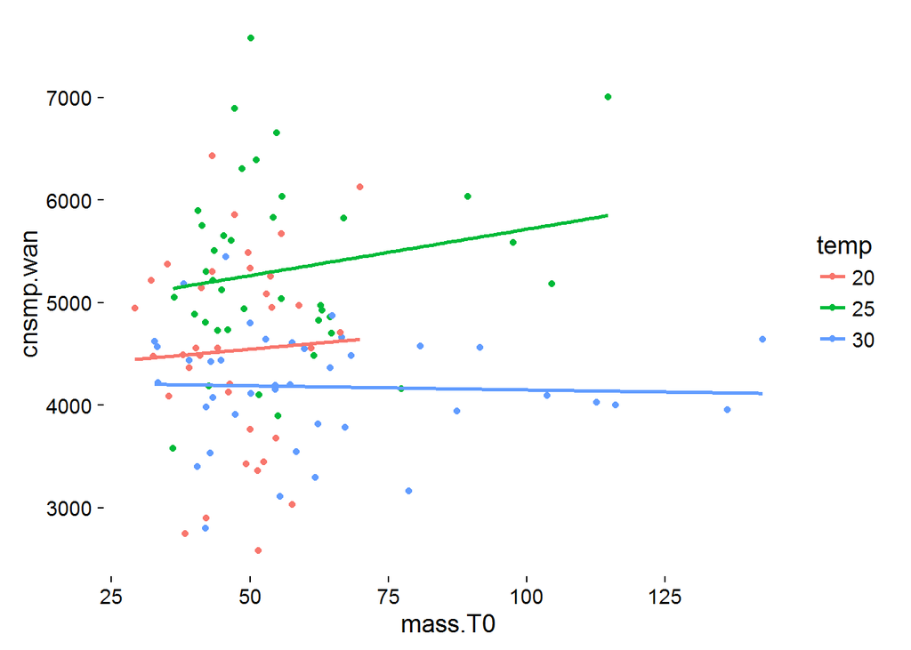

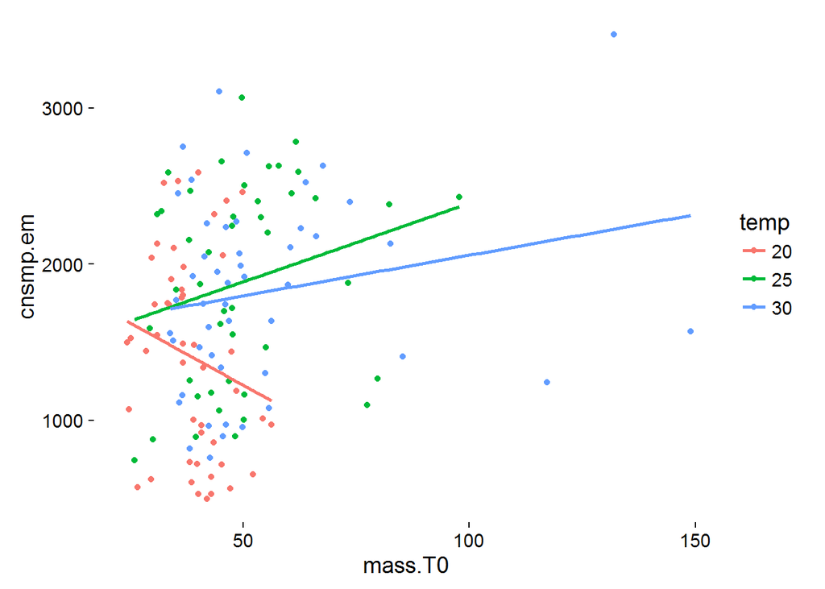